# modeling stroop effects (RTs) with RSA coding schemes

michael freund

2020-07-25

# 1 an initial look (diagnostics, outliers, etc…)

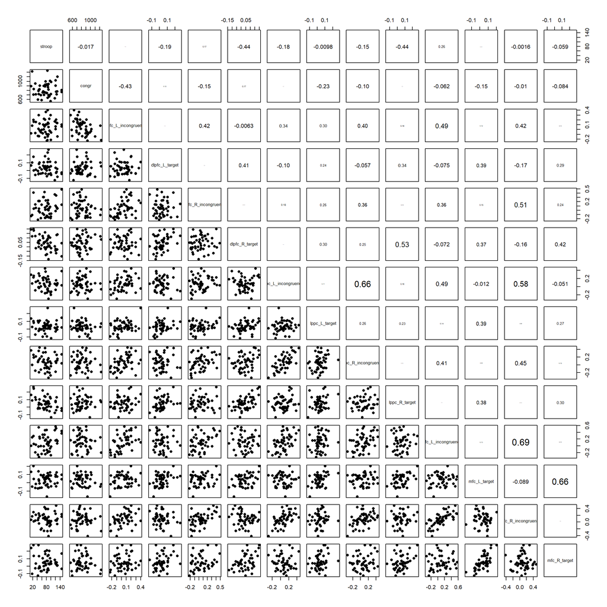

```r
pairs(w.super[ids$is.analysis.group, c("stroop", "congr", sort(hyps))], pch = 16, upper.panel = panel.cor)
```

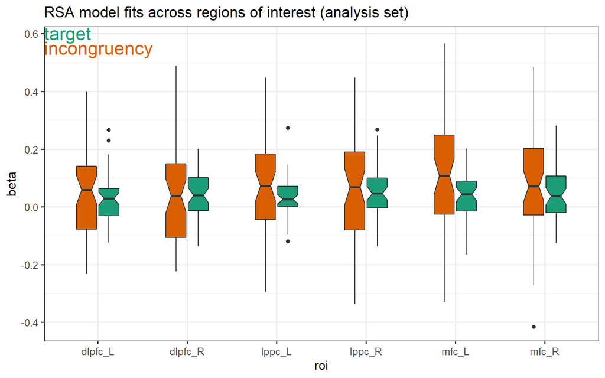

```r
d.super %>%

  filter(is.analysis.group, id %in% hyps) %>%

  ggplot(aes(roi, beta, fill = param)) +
  geom_boxplot(notch = TRUE, width = 0.5) +
  scale_fill_manual(values = colors.model) +

  annotate(
    "text", x = -Inf, y = Inf, label = "target", color = colors.model["target"],
    hjust = 0, vjust = 1, size = 6
    ) +
  annotate(
    "text", x = -Inf, y = 0.575, label = "incongruency", color = colors.model["incongruency"],
    hjust = 0, vjust = 1, size = 6
    ) +

  theme(legend.position = "none") +
  labs(title = "RSA model fits across regions of interest (analysis set)")
```

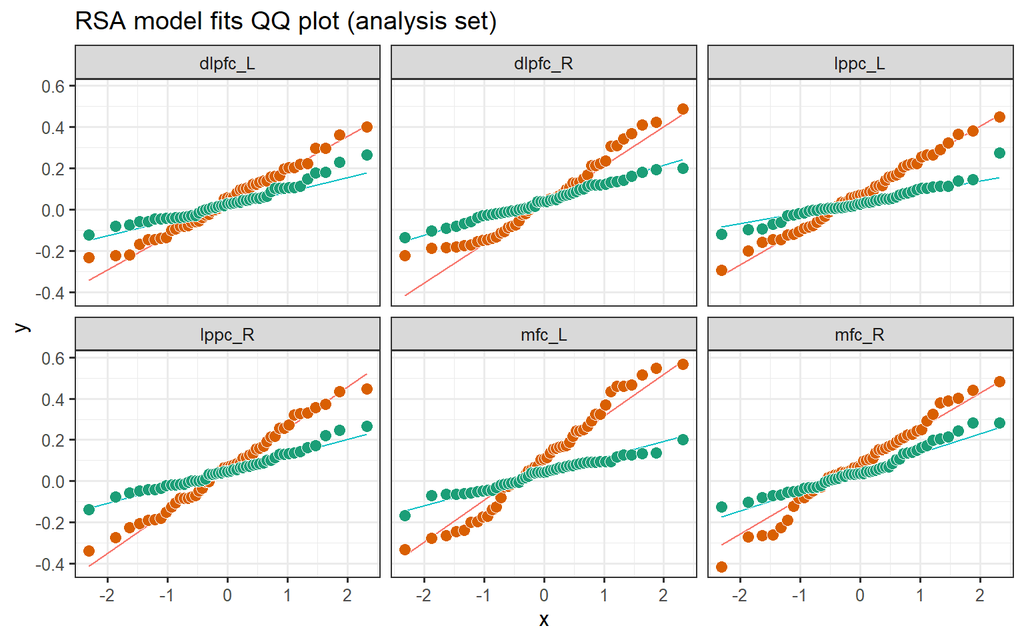

```r
d.super %>%

  filter(is.analysis.group, id %in% hyps) %>%

  ggplot(aes(sample = beta, fill = param, color = param)) +
  stat_qq_line() +
  stat_qq(shape = 21, color = "white", size = 3) +
  facet_wrap(vars(roi)) +

  scale_fill_manual(values = colors.model) +

  theme(legend.position = "none") +
  labs(title = "RSA model fits QQ plot (analysis set)")
```

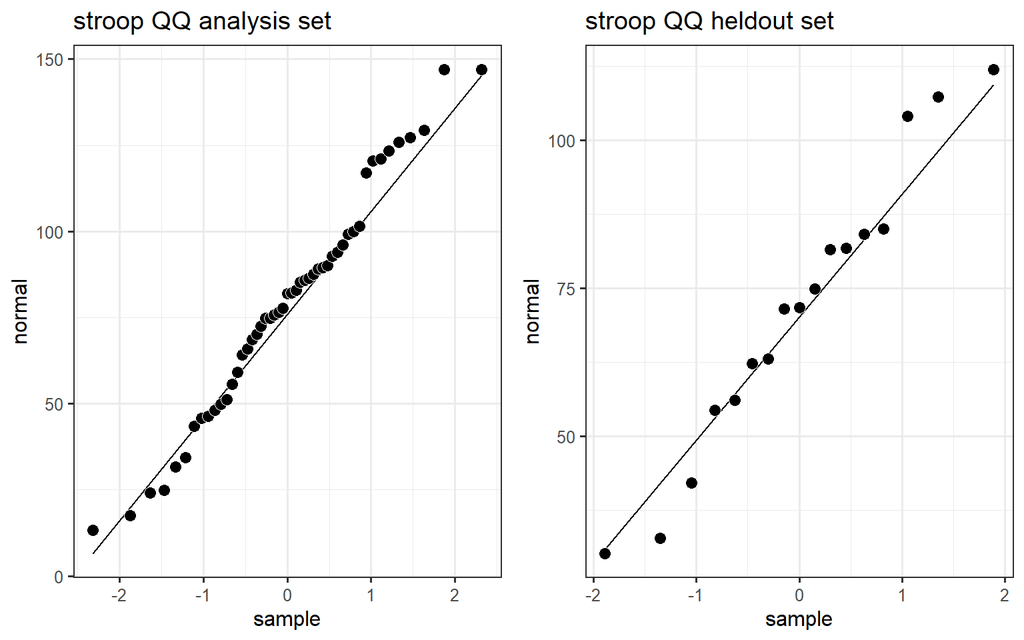

```r
grid.arrange(

  w.super %>%

    filter(is.analysis.group) %>%

    ggplot(aes(sample = stroop)) +
    stat_qq_line() +
    stat_qq(shape = 21, color = "white", fill = "black", size = 3) +
    labs(x = "sample", y = "normal", title = "stroop QQ analysis set"),

  w.super %>%

    filter(!is.analysis.group) %>%

    ggplot(aes(sample = stroop)) +
    stat_qq_line() +
    stat_qq(shape = 21, color = "white", fill = "black", size = 3) +
    labs(x = "sample", y = "normal", title = "stroop QQ heldout set"),

  ncol = 2

)
```

# 2 Are target and incongruency coding schemes dissociated across MFC and DLPFC/LPPC?

- “superparcel”-based analysis
  - anatomically defined collections of contiguous Glasser-atlas parcels
  - all superparcels lateralized
  - MFC: from preSMA/“cingulate motor zone” to dACC
    - SCEF, 8BM, p32pr, a32pr
  - DLPFC: parcels tiling MFG
  - LPPC: parcels tiling both banks and fundus of IPS, from occipital lobe to S1
- hypotheses:
  - within MFC: $r_{\text{(stroop, incon)}} > 0, |r_{\text{(stroop, target)}}| \not> 0$
    - stroop~MFC association positive (+), limited to incongruent scheme
  - within DLPFC and LPPC: $|r_{\text{(stroop, incon)}}| \not> 0, r_{\text{(stroop, target)}} < 0$
    - stroop~DLPFC/LPPC association negative (-), limited to target scheme

## 2.1 identify significant brain–behavior correlations among hypothesized region*schemes

- test each hypothesized association separately in each hemisphere
  - DLPFC_target * (R, L)
  - LPPC_target * (R, L)
  - MFC_incongruency * (R, L)
- use HLM framework:
  - fixed effects of trial-level **trial.type** (congruent, incongruent), subject-level **region_scheme** (e.g., dlpfc_R_target), and their cross-level interaction (e.g., **trial.type*****dlpfc_R_target**)
  - random effects of subject, with random slope/intercept of trial.type (and slope–intercept correlation)
  - assume residual variances are heterogeneous across subjects (as they are)
    - use nlme::lme() to estimate appropriate residual scaling factor per subj
- correct p-values across hemisphere, within each region*scheme

```r
## models ----

fit1.het.trim <- readRDS(here("out", "behav", "fit1-het-trim_group201902.RDS"))  ## behavioral model

d.dissoc.hlm <- full_join(
  fit1.het.trim$data %>% filter(!is.far.out),
  w.super %>% filter(is.analysis.group) %>% ungroup %>% select(subj, one_of(hyps)),
  by = "subj"
)

d.dissoc.hlm %<>% group_by(subj) %>% mutate(rt.s = scale(rt))

mods.lme <- list(
  dlpfc_L_targ = update(fit1.het.trim, rt.s ~ . + trial.type * dlpfc_L_target, data = d.dissoc.hlm),
  dlpfc_R_targ = update(fit1.het.trim, rt.s ~ . + trial.type * dlpfc_R_target, data = d.dissoc.hlm),
  lppc_L_targ  = update(fit1.het.trim, rt.s ~ . + trial.type * lppc_L_target, data = d.dissoc.hlm),
  lppc_R_targ  = update(fit1.het.trim, rt.s ~ . + trial.type * lppc_R_target, data = d.dissoc.hlm),
  mfc_L_incon  = update(fit1.het.trim, rt.s ~ . + trial.type * mfc_L_incongruency, data = d.dissoc.hlm),
  mfc_R_incon  = update(fit1.het.trim, rt.s ~ . + trial.type * mfc_R_incongruency, data = d.dissoc.hlm)
)
sums.lme <- lapply(mods.lme, summary)
pvals.lme <- lapply(sums.lme, function(.) coef(.)[4, "p-value"])
pvals.lme <- reshape2::melt(bind_rows(pvals.lme), value.name = "p", variable = "id")
pvals.lme$group  <- rep(1:3, each = 2)
pvals.lme %<>% group_by(group) %>% mutate(p.fdr = p.adjust(p, method = "fdr"))

lapply(sums.lme, coef)  ## print results
```

```
## $dlpfc_L_targ
##                                  Value Std.Error    DF t-value   p-value
## (Intercept)                    -0.3968   0.03310 10090 -11.988 6.830e-33
## trial.typeincon                 0.5988   0.04758 10090  12.586 4.705e-36
## dlpfc_L_target                  0.4177   0.38471    47   1.086 2.832e-01
## trial.typeincon:dlpfc_L_target -0.6384   0.55275 10090  -1.155 2.481e-01
##
## $dlpfc_R_targ
##                                  Value Std.Error    DF t-value   p-value
## (Intercept)                    -0.4295   0.03168 10090 -13.558 1.645e-41
## trial.typeincon                 0.6473   0.04521 10090  14.316 4.897e-46
## dlpfc_R_target                  1.1333   0.35867    47   3.160 2.761e-03
## trial.typeincon:dlpfc_R_target -1.6982   0.51139 10090  -3.321 9.006e-04
##
## $lppc_L_targ
##                                 Value Std.Error    DF  t-value   p-value
## (Intercept)                   -0.3687   0.03438 10090 -10.7254 1.077e-26
## trial.typeincon                0.5555   0.04936 10090  11.2530 3.342e-29
## lppc_L_target                 -0.4240   0.45368    47  -0.9345 3.548e-01
## trial.typeincon:lppc_L_target  0.6598   0.65247 10090   1.0113 3.119e-01
##
## $lppc_R_targ
##                                 Value Std.Error    DF t-value   p-value
## (Intercept)                   -0.4278   0.03501 10090 -12.218 4.348e-34
## trial.typeincon                0.6458   0.05011 10090  12.888 1.041e-37
## lppc_R_target                  0.8396   0.36201    47   2.319 2.477e-02
## trial.typeincon:lppc_R_target -1.2767   0.51708 10090  -2.469 1.356e-02
##
## $mfc_L_incon
##                                      Value Std.Error    DF t-value   p-value
## (Intercept)                        -0.3633   0.03357 10090 -10.823 3.791e-27
## trial.typeincon                     0.5475   0.04816 10090  11.369 9.029e-30
## mfc_L_incongruency                 -0.1820   0.13011    47  -1.399 1.685e-01
## trial.typeincon:mfc_L_incongruency  0.2794   0.18683 10090   1.496 1.348e-01
##
## $mfc_R_incon
##                                       Value Std.Error    DF  t-value   p-value
## (Intercept)                        -0.38534   0.03375 10090 -11.4171 5.245e-30
## trial.typeincon                     0.58116   0.04859 10090  11.9617 9.389e-33
## mfc_R_incongruency                  0.02892   0.16154    47   0.1790 8.587e-01
## trial.typeincon:mfc_R_incongruency -0.04277   0.23237 10090  -0.1841 8.540e-01
```

```r
pvals.lme  ## p values (corrected)
```

```
## # A tibble: 6 x 4
## # Groups:   group [3]
##   id                  p group   p.fdr
##   <fct>           <dbl> <int>   <dbl>
## 1 dlpfc_L_targ 0.248        1 0.248
## 2 dlpfc_R_targ 0.000901     1 0.00180
## 3 lppc_L_targ  0.312        2 0.312
## 4 lppc_R_targ  0.0136       2 0.0271
## 5 mfc_L_incon  0.135        3 0.270
## 6 mfc_R_incon  0.854        3 0.854
```

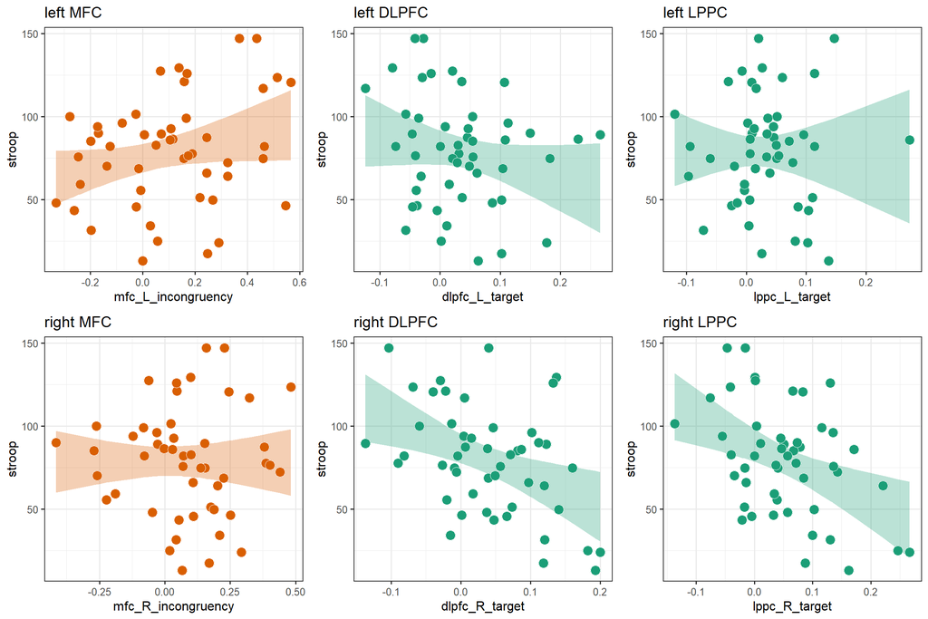

```r
## plot ----

w.super %>%

  filter(is.analysis.group) %>%

  {

    grid.arrange(

      ggplot(., aes(mfc_L_incongruency, stroop)) +
        stat_boot_ci(n = 1E4, alpha = 0.3, fill = colors.model["incongruency"]) +
        geom_point(fill = colors.model["incongruency"], color = "white", shape = 21, size = 4) +
        ggtitle("left MFC"),

      ggplot(., aes(dlpfc_L_target, stroop)) +
        stat_boot_ci(n = 1E4, alpha = 0.3, fill = colors.model["target"]) +
        geom_point(fill = colors.model["target"], color = "white", shape = 21, size = 4) +
        ggtitle("left DLPFC"),

      ggplot(., aes(lppc_L_target, stroop)) +
        stat_boot_ci(n = 1E4, alpha = 0.3, fill = colors.model["target"]) +
        geom_point(fill = colors.model["target"], color = "white", shape = 21, size = 4) +
        ggtitle("left LPPC"),

      ggplot(., aes(mfc_R_incongruency, stroop)) +
        stat_boot_ci(n = 1E4, alpha = 0.3, fill = colors.model["incongruency"]) +
        geom_point(fill = colors.model["incongruency"], color = "white", shape = 21, size = 4) +
        ggtitle("right MFC"),

      ggplot(., aes(dlpfc_R_target, stroop)) +
        stat_boot_ci(n = 1E4, alpha = 0.3, fill = colors.model["target"]) +
        geom_point(fill = colors.model["target"], color = "white", shape = 21, size = 4) +
        ggtitle("right DLPFC"),

      ggplot(., aes(lppc_R_target, stroop)) +
        stat_boot_ci(n = 1E4, alpha = 0.3, fill = colors.model["target"]) +
        geom_point(fill = colors.model["target"], color = "white", shape = 21, size = 4) +
        ggtitle("right LPPC"),

      ncol = 3

    )

  }
```

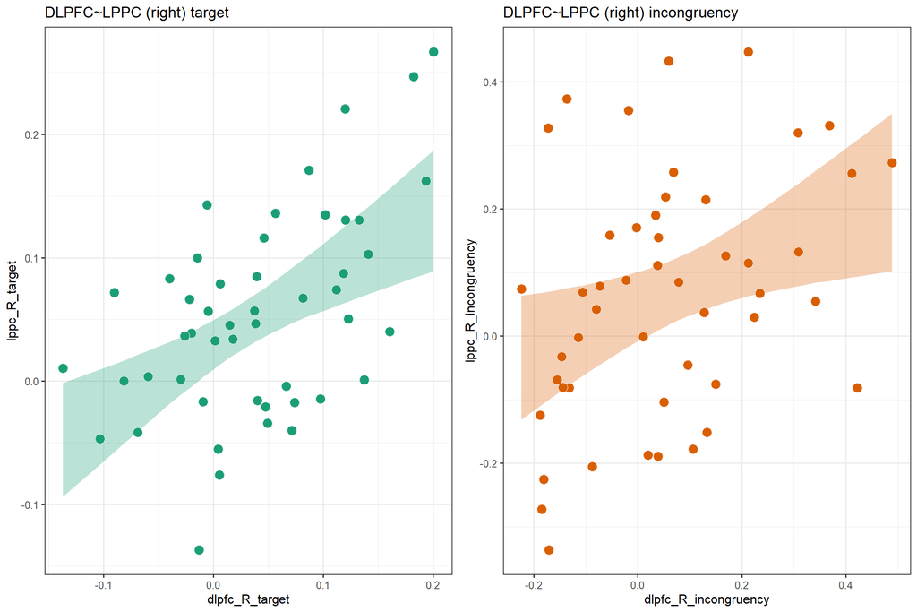

```r
w.super %>%

  filter(is.analysis.group) %>%

  {

    grid.arrange(

        ggplot(., aes(dlpfc_R_target, lppc_R_target)) +
        stat_boot_ci(n = 1E4, alpha = 0.3, fill = colors.model["target"]) +
        geom_point(fill = colors.model["target"], color = "white", shape = 21, size = 4) +
        ggtitle("DLPFC~LPPC (right) target"),

      ggplot(., aes(dlpfc_R_incongruency, lppc_R_incongruency)) +
        stat_boot_ci(n = 1E4, alpha = 0.3, fill = colors.model["incongruency"]) +
        geom_point(fill = colors.model["incongruency"], color = "white", shape = 21, size = 4) +
        ggtitle("DLPFC~LPPC (right) incongruency"),

      ncol = 2

    )

  }
```

```r
cors.lfp <- w.super %>%
  filter(is.analysis.group) %>%
  summarize(
    r_target = cor(dlpfc_R_target, lppc_R_target),
    r_incongruency = cor(dlpfc_R_incongruency, lppc_R_incongruency)
    )

cors.lfp
```

```
## # A tibble: 1 x 4
## # Groups:   scheme [1]
##   scheme      is.analysis.group r_target r_incongruency
##   <chr>       <lgl>                <dbl>          <dbl>
## 1 superparcel TRUE                 0.532          0.355
```

- dlpfc_R_target and lpp_R_target correlated at 0.53
- create composite variable “lateral frontoparietal cortex” or lfp:
  - for simplicity of plotting / display

```r
d.dissoc.hlm$lfp_R_target <- (d.dissoc.hlm$dlpfc_R_target + d.dissoc.hlm$lppc_R_target) / 2
d.dissoc.hlm$lfp_R_incongruency <- (d.dissoc.hlm$dlpfc_R_incongruency + d.dissoc.hlm$lppc_R_incongruency) / 2

w.super$lfp_R_target <- (w.super$dlpfc_R_target + w.super$lppc_R_target) / 2
w.super$lfp_R_incongruency <- (w.super$dlpfc_R_incongruency + w.super$lppc_R_incongruency) / 2

d.super %<>%

  {
      bind_rows(
        .,
        filter(., roi %in% c("dlpfc_R", "lppc_R"), param %in% c("target", "incongruency")) %>%
        group_by(subj, scheme, is.analysis.group, param) %>%
        summarize(
          congr = unique(congr), stroop = unique(stroop),
          beta = mean(beta), partr = mean(partr), beta.s = mean(beta.s)
          ) %>%
          ungroup %>%
        mutate(roi = "lfp_R", id = paste0(roi, "_", param))
      )
  }
```

### 2.1.1 results

- **moderate relationship**: stroop effect ~ (-) dlpfc_R_target and lpp_R_target
  - each association survives multiple comparison correction
- **weak relationship**: stroop effect ~ (+) left MFC incongruency coding
  - association does not survive multiple comparison correction

## 2.2 Test for single dissociations

```
* within regions identified, test whether brain--behavior slopes differ across coding schemes.
  * dlpfc_R, lppc_R, : targ < incon
  * mfc_L: incon > targ
```

```r
## models ----

mods.lme$dlpfc_R <- update(mods.lme$dlpfc_R_targ, . ~ . + trial.type * dlpfc_R_incongruency)
mods.lme$lppc_R <- update(mods.lme$lppc_R_targ, . ~ . + trial.type * lppc_R_incongruency)
mods.lme$mfc_L <- update(mods.lme$mfc_L_incon, . ~ . + trial.type * mfc_L_target)

W.single <- rbind(target_vs_incongruency = c(0, 0, 0, 0, 1, -1))

summary(mods.lme$dlpfc_R)
```

```
## Linear mixed-effects model fit by REML
##  Data: d.dissoc.hlm
##   Subset: !is.far.out
##     AIC   BIC logLik
##   27926 28345 -13905
##
## Random effects:
##  Formula: ~trial.type | subj
##  Structure: General positive-definite, Log-Cholesky parametrization
##                 StdDev Corr
## (Intercept)     0.1591 (Intr)
## trial.typeincon 0.2407 -1
## Residual        0.8640
##
## Variance function:
##  Structure: Different standard deviations per stratum
##  Formula: ~1 | subj
##  Parameter estimates:
##      107321      123117      130114      132017      138837      141422
##      1.0000      1.0879      1.1167      1.0723      1.0158      1.1319
##      150423      158136      160830      161832      165032      171330
##      1.1249      1.0643      1.1386      1.1551      1.1579      1.1208
##      178243      178950      182436      197449      203418      204319
##      1.0977      1.1577      1.1536      1.1352      1.0646      1.1549
##      300618      317332      346945      352738      448347      580650
##      1.1244      1.0918      1.1120      1.0925      1.1026      1.1387
##      594156      601127      765864      814649      843151      849971
##      1.0950      1.0609      1.0433      1.1252      1.1217      1.1598
##      873968      877168 DMCC1971064 DMCC2442951 DMCC3062542 DMCC4854075
##      1.1122      1.1251      1.0892      1.0518      1.1231      1.1476
## DMCC5009144 DMCC6418065 DMCC6484785 DMCC6661074 DMCC6671683 DMCC6721369
##      1.1171      0.9996      1.1477      1.0803      1.0167      1.0154
## DMCC7297690 DMCC7921988 DMCC8033964 DMCC8050964 DMCC9441378 DMCC9478705
##      1.1349      1.0691      1.1488      1.0844      1.0585      1.1468
## DMCC9953810
##      1.0409
## Fixed effects: rt.s ~ trial.type + dlpfc_R_target + dlpfc_R_incongruency + trial.type:dlpfc_R_target +      trial.type:dlpfc_R_incongruency
##                                        Value Std.Error    DF t-value p-value
## (Intercept)                          -0.4202    0.0321 10089 -13.079  0.0000
## trial.typeincon                       0.6329    0.0458 10089  13.833  0.0000
```

[output cut: 9 more lines]

```
## trial.typeincon:dlpfc_R_target        0.401 -0.426 -0.941     0.073
## trial.typeincon:dlpfc_R_incongruency  0.204 -0.216  0.073    -0.942
##                                      trl.typncn:dlpfc_R_t
## trial.typeincon
## dlpfc_R_target
## dlpfc_R_incongruency
## trial.typeincon:dlpfc_R_target
## trial.typeincon:dlpfc_R_incongruency -0.078
##
## Standardized Within-Group Residuals:
##     Min      Q1     Med      Q3     Max
## -3.5345 -0.6815 -0.1531  0.5045  4.7222
##
## Number of Observations: 10141
## Number of Groups: 49
```

```r
(contrast.dlpfc_R <- summary(glht(mods.lme$dlpfc_R, W.single), test = adjusted("none")))  ## predicted: negative
```

```
##
##   Simultaneous Tests for General Linear Hypotheses
##
## Fit: lme.formula(fixed = rt.s ~ trial.type + dlpfc_R_target + dlpfc_R_incongruency +
##     trial.type:dlpfc_R_target + trial.type:dlpfc_R_incongruency,
##     data = d.dissoc.hlm, random = ~trial.type | subj, weights = varIdent(form = ~1 |
##         subj), subset = !is.far.out, method = "REML", control = lmeControl(maxIter = 1e+05,
##         msMaxIter = 1e+05, niterEM = 1e+05, msMaxEval = 1e+05))
##
## Linear Hypotheses:
##                             Estimate Std. Error z value Pr(>|z|)
## target_vs_incongruency == 0   -2.077      0.568   -3.66  0.00026 ***
## ---
## Signif. codes:  0 '***' 0.001 '**' 0.01 '*' 0.05 '.' 0.1 ' ' 1
## (Adjusted p values reported -- none method)
```

```r
summary(mods.lme$lppc_R)
```

```
## Linear mixed-effects model fit by REML
##  Data: d.dissoc.hlm
##   Subset: !is.far.out
##     AIC   BIC logLik
##   27932 28351 -13908
##
## Random effects:
##  Formula: ~trial.type | subj
##  Structure: General positive-definite, Log-Cholesky parametrization
##                 StdDev Corr
## (Intercept)     0.1729 (Intr)
## trial.typeincon 0.2614 -1
## Residual        0.8634
##
## Variance function:
##  Structure: Different standard deviations per stratum
##  Formula: ~1 | subj
##  Parameter estimates:
##      107321      123117      130114      132017      138837      141422
##      1.0000      1.0888      1.1174      1.0733      1.0164      1.1323
##      150423      158136      160830      161832      165032      171330
##      1.1253      1.0652      1.1408      1.1564      1.1585      1.1212
##      178243      178950      182436      197449      203418      204319
##      1.0979      1.1590      1.1552      1.1364      1.0652      1.1566
##      300618      317332      346945      352738      448347      580650
##      1.1253      1.0927      1.1125      1.0928      1.1031      1.1396
##      594156      601127      765864      814649      843151      849971
##      1.0957      1.0611      1.0434      1.1259      1.1226      1.1603
##      873968      877168 DMCC1971064 DMCC2442951 DMCC3062542 DMCC4854075
##      1.1132      1.1259      1.0897      1.0526      1.1239      1.1474
## DMCC5009144 DMCC6418065 DMCC6484785 DMCC6661074 DMCC6671683 DMCC6721369
##      1.1178      0.9995      1.1485      1.0808      1.0178      1.0160
## DMCC7297690 DMCC7921988 DMCC8033964 DMCC8050964 DMCC9441378 DMCC9478705
##      1.1358      1.0699      1.1494      1.0850      1.0592      1.1477
## DMCC9953810
##      1.0417
## Fixed effects: rt.s ~ trial.type + lppc_R_target + lppc_R_incongruency + trial.type:lppc_R_target +      trial.type:lppc_R_incongruency
##                                       Value Std.Error    DF t-value p-value
## (Intercept)                         -0.4318    0.0363 10089 -11.888  0.0000
## trial.typeincon                      0.6511    0.0520 10089  12.513  0.0000
```

[output cut: 9 more lines]

```
## trial.typeincon:lppc_R_target        0.483 -0.509 -0.947    0.072
## trial.typeincon:lppc_R_incongruency  0.227 -0.239  0.072   -0.948
##                                     trl.typncn:lppc_R_t
## trial.typeincon
## lppc_R_target
## lppc_R_incongruency
## trial.typeincon:lppc_R_target
## trial.typeincon:lppc_R_incongruency -0.076
##
## Standardized Within-Group Residuals:
##     Min      Q1     Med      Q3     Max
## -3.5204 -0.6798 -0.1559  0.4994  4.7139
##
## Number of Observations: 10141
## Number of Groups: 49
```

```r
(contrast.lppc_R <- summary(glht(mods.lme$lppc_R, W.single), test = adjusted("none")))  ## predicted: negative
```

```
##
##   Simultaneous Tests for General Linear Hypotheses
##
## Fit: lme.formula(fixed = rt.s ~ trial.type + lppc_R_target + lppc_R_incongruency +
##     trial.type:lppc_R_target + trial.type:lppc_R_incongruency,
##     data = d.dissoc.hlm, random = ~trial.type | subj, weights = varIdent(form = ~1 |
##         subj), subset = !is.far.out, method = "REML", control = lmeControl(maxIter = 1e+05,
##         msMaxIter = 1e+05, niterEM = 1e+05, msMaxEval = 1e+05))
##
## Linear Hypotheses:
##                             Estimate Std. Error z value Pr(>|z|)
## target_vs_incongruency == 0   -1.162      0.585   -1.99    0.047 *
## ---
## Signif. codes:  0 '***' 0.001 '**' 0.01 '*' 0.05 '.' 0.1 ' ' 1
## (Adjusted p values reported -- none method)
```

```r
summary(mods.lme$mfc_L)
```

```
## Linear mixed-effects model fit by REML
##  Data: d.dissoc.hlm
##   Subset: !is.far.out
##     AIC   BIC logLik
##   27935 28354 -13910
##
## Random effects:
##  Formula: ~trial.type | subj
##  Structure: General positive-definite, Log-Cholesky parametrization
##                 StdDev Corr
## (Intercept)     0.1810 (Intr)
## trial.typeincon 0.2733 -1
## Residual        0.8628
##
## Variance function:
##  Structure: Different standard deviations per stratum
##  Formula: ~1 | subj
##  Parameter estimates:
##      107321      123117      130114      132017      138837      141422
##       1.000       1.090       1.118       1.074       1.017       1.133
##      150423      158136      160830      161832      165032      171330
##       1.126       1.066       1.140       1.156       1.161       1.123
##      178243      178950      182436      197449      203418      204319
##       1.099       1.161       1.156       1.137       1.066       1.157
##      300618      317332      346945      352738      448347      580650
##       1.126       1.093       1.113       1.094       1.104       1.141
##      594156      601127      765864      814649      843151      849971
##       1.096       1.061       1.044       1.127       1.123       1.160
##      873968      877168 DMCC1971064 DMCC2442951 DMCC3062542 DMCC4854075
##       1.114       1.127       1.091       1.054       1.125       1.148
## DMCC5009144 DMCC6418065 DMCC6484785 DMCC6661074 DMCC6671683 DMCC6721369
##       1.119       1.001       1.149       1.082       1.017       1.017
## DMCC7297690 DMCC7921988 DMCC8033964 DMCC8050964 DMCC9441378 DMCC9478705
##       1.137       1.071       1.151       1.086       1.060       1.148
## DMCC9953810
##       1.043
## Fixed effects: rt.s ~ trial.type + mfc_L_incongruency + mfc_L_target + trial.type:mfc_L_incongruency +      trial.type:mfc_L_target
##                                      Value Std.Error    DF t-value p-value
## (Intercept)                        -0.3532    0.0366 10089  -9.655  0.0000
## trial.typeincon                     0.5315    0.0524 10089  10.138  0.0000
```

[output cut: 9 more lines]

```
## trial.typeincon:mfc_L_incongruency  0.322 -0.338 -0.952   0.116
## trial.typeincon:mfc_L_target        0.367 -0.386  0.117  -0.950
##                                    trl.typncn:mfc_L_n
## trial.typeincon
## mfc_L_incongruency
## mfc_L_target
## trial.typeincon:mfc_L_incongruency
## trial.typeincon:mfc_L_target       -0.123
##
## Standardized Within-Group Residuals:
##     Min      Q1     Med      Q3     Max
## -3.5504 -0.6808 -0.1551  0.4995  4.7134
##
## Number of Observations: 10141
## Number of Groups: 49
```

```r
(contrast.mfc_L <- summary(glht(mods.lme$mfc_L, W.single), test = adjusted("none")))  ## predicted: positive
```

```
##
##   Simultaneous Tests for General Linear Hypotheses
##
## Fit: lme.formula(fixed = rt.s ~ trial.type + mfc_L_incongruency +
##     mfc_L_target + trial.type:mfc_L_incongruency + trial.type:mfc_L_target,
##     data = d.dissoc.hlm, random = ~trial.type | subj, weights = varIdent(form = ~1 |
##         subj), subset = !is.far.out, method = "REML", control = lmeControl(maxIter = 1e+05,
##         msMaxIter = 1e+05, niterEM = 1e+05, msMaxEval = 1e+05))
##
## Linear Hypotheses:
##                             Estimate Std. Error z value Pr(>|z|)
## target_vs_incongruency == 0   -0.237      0.682   -0.35     0.73
## (Adjusted p values reported -- none method)
```

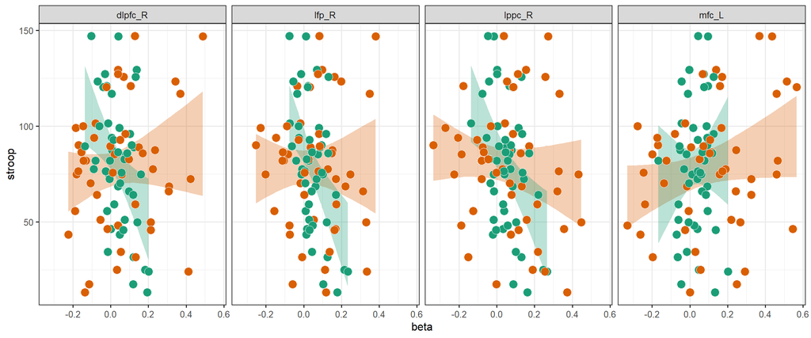

```r
## plot -----

d.super %>%

  filter(
    is.analysis.group,
    roi %in% c("dlpfc_R", "lppc_R", "mfc_L", "lfp_R"), param %in% c("target", "incongruency")
    ) %>%

  ggplot(., aes(beta, stroop, fill = param)) +
  stat_boot_ci(n = 1E4, alpha = 0.3) +
  geom_point(color = "white", shape = 21, size = 4) +
  facet_grid(cols = vars(roi)) +
  scale_fill_manual(values = colors.model) +

  theme(legend.position = "none")
```

## 2.3 Jointly test for double dissociation

all regressors in single model

```r
## model ----
mods.lme$mfc_L.lfp_R <- lme(

  rt.s ~
    trial.type * lfp_R_target +
    trial.type * lfp_R_incongruency +
    trial.type * mfc_L_target +
    trial.type * mfc_L_incongruency,

  random  = ~ trial.type | subj,
  data    = d.dissoc.hlm,
  weights = varIdent(form = ~ 1 | subj),
  control = lmeControl(maxIter = 1e5, msMaxIter = 1e5, niterEM = 1e5, msMaxEval = 1e5),
  method  = "REML"

)

summary(mods.lme$mfc_L.lfp_R)
```

```
## Linear mixed-effects model fit by REML
##  Data: d.dissoc.hlm
##     AIC   BIC logLik
##   27932 28379 -13904
##
## Random effects:
##  Formula: ~trial.type | subj
##  Structure: General positive-definite, Log-Cholesky parametrization
##                 StdDev Corr
## (Intercept)     0.1467 (Intr)
## trial.typeincon 0.2211 -1
## Residual        0.8652
##
## Variance function:
##  Structure: Different standard deviations per stratum
##  Formula: ~1 | subj
##  Parameter estimates:
##      107321      123117      130114      132017      138837      141422
##      1.0000      1.0863      1.1155      1.0709      1.0139      1.1302
##      150423      158136      160830      161832      165032      171330
##      1.1229      1.0629      1.1382      1.1527      1.1553      1.1192
##      178243      178950      182436      197449      203418      204319
##      1.0959      1.1569      1.1521      1.1343      1.0630      1.1536
##      300618      317332      346945      352738      448347      580650
##      1.1235      1.0900      1.1099      1.0908      1.1008      1.1373
##      594156      601127      765864      814649      843151      849971
##      1.0933      1.0590      1.0412      1.1237      1.1201      1.1548
##      873968      877168 DMCC1971064 DMCC2442951 DMCC3062542 DMCC4854075
##      1.1111      1.1236      1.0875      1.0524      1.1216      1.1450
## DMCC5009144 DMCC6418065 DMCC6484785 DMCC6661074 DMCC6671683 DMCC6721369
##      1.1156      0.9975      1.1458      1.0785      1.0161      1.0142
## DMCC7297690 DMCC7921988 DMCC8033964 DMCC8050964 DMCC9441378 DMCC9478705
##      1.1334      1.0674      1.1473      1.0830      1.0570      1.1474
## DMCC9953810
##      1.0394
## Fixed effects: rt.s ~ trial.type * lfp_R_target + trial.type * lfp_R_incongruency +      trial.type * mfc_L_target + trial.type * mfc_L_incongruency
##                                      Value Std.Error    DF t-value p-value
## (Intercept)                        -0.4122    0.0347 10087 -11.871  0.0000
## trial.typeincon                     0.6209    0.0489 10087  12.693  0.0000
## lfp_R_target                        1.7540    0.4310    44   4.069  0.0002
```

[output cut: 30 more lines]

```
## lfp_R_target
## lfp_R_incongruency
## mfc_L_target
## mfc_L_incongruency
## trial.typeincon:lfp_R_target
## trial.typeincon:lfp_R_incongruency
## trial.typeincon:mfc_L_target       -0.002
## trial.typeincon:mfc_L_incongruency -0.477             -0.129
##
## Standardized Within-Group Residuals:
##     Min      Q1     Med      Q3     Max
## -3.5356 -0.6828 -0.1544  0.5056  4.7202
##
## Number of Observations: 10141
## Number of Groups: 49
```

```r
W <- rbind(
  "targ|C,lfp" = c(0, 0, 1, 0, 0, 0, 0, 0, 0, 0),
  "targ|C,mfc" = c(0, 0, 0, 0, 1, 0, 0, 0, 0, 0),
  "targ|I,lfp" = c(0, 0, 1, 0, 0, 0, 1, 0, 0, 0),
  "targ|I,mfc" = c(0, 0, 0, 0, 1, 0, 0, 0, 1, 0),
  "stroop*(targ-incon)|lfp"      = c(0, 0, 0, 0, 0, 0, 1, -1, 0, 0),  ## 2-way interaction within lfp (tt*scheme)
  "stroop*(targ-incon)|mfc"      = c(0, 0, 0, 0, 0, 0, 0, 0, 1, -1),  ## 2-way interaction within mfc (tt*scheme)
  "stroop*(targ-incon)(lfp-mfc)" = c(0, 0, 0, 0, 0, 0, 1, -1, -1, 1)  ## 3-way interaction
  )

(contrast.mfc_L.lfp_R <- summary(glht(mods.lme$mfc_L.lfp_R, W), test = adjusted("none")))
```

```
##
##   Simultaneous Tests for General Linear Hypotheses
##
## Fit: lme.formula(fixed = rt.s ~ trial.type * lfp_R_target + trial.type *
##     lfp_R_incongruency + trial.type * mfc_L_target + trial.type *
##     mfc_L_incongruency, data = d.dissoc.hlm, random = ~trial.type |
##     subj, weights = varIdent(form = ~1 | subj), method = "REML",
##     control = lmeControl(maxIter = 1e+05, msMaxIter = 1e+05,
##         niterEM = 1e+05, msMaxEval = 1e+05))
##
## Linear Hypotheses:
##                                   Estimate Std. Error z value Pr(>|z|)
## targ|C,lfp == 0                      1.754      0.431    4.07  4.7e-05 ***
## targ|C,mfc == 0                     -1.091      0.427   -2.55  0.01069 *
## targ|I,lfp == 0                     -0.909      0.257   -3.55  0.00039 ***
## targ|I,mfc == 0                      0.581      0.254    2.28  0.02238 *
## stroop*(targ-incon)|lfp == 0        -2.716      0.717   -3.79  0.00015 ***
## stroop*(targ-incon)|mfc == 0         1.493      0.652    2.29  0.02195 *
## stroop*(targ-incon)(lfp-mfc) == 0   -4.208      1.158   -3.63  0.00028 ***
## ---
## Signif. codes:  0 '***' 0.001 '**' 0.01 '*' 0.05 '.' 0.1 ' ' 1
## (Adjusted p values reported -- none method)
```

```r
## plot ----

## refit model to get level-2 residuals sans mfc_L_target:

mods.lme$sans.mfc.targ <- update(mods.lme$mfc_L.lfp_R, . ~ . - trial.type * mfc_L_target)

resids <- data.frame(

  stroop = w.super %>% filter(is.analysis.group) %>% .$stroop,

  stroop.resid = ranef(mods.lme$sans.mfc.targ)[, 2],

  mfc_L_targ.resid = lm(
    mfc_L_target ~
      lfp_R_target + lfp_R_incongruency + mfc_L_incongruency,
    w.super %>% filter(is.analysis.group)
    )$residuals,

  mfc_L_targ = w.super %>% filter(is.analysis.group) %>% .$mfc_L_target

)

cor(resids)
```

```
##                   stroop stroop.resid mfc_L_targ.resid mfc_L_targ
## stroop           1.00000      0.52602           0.2868    0.07235
## stroop.resid     0.52602      1.00000           0.2569   -0.09618
## mfc_L_targ.resid 0.28676      0.25688           1.0000    0.89170
## mfc_L_targ       0.07235     -0.09618           0.8917    1.00000
```

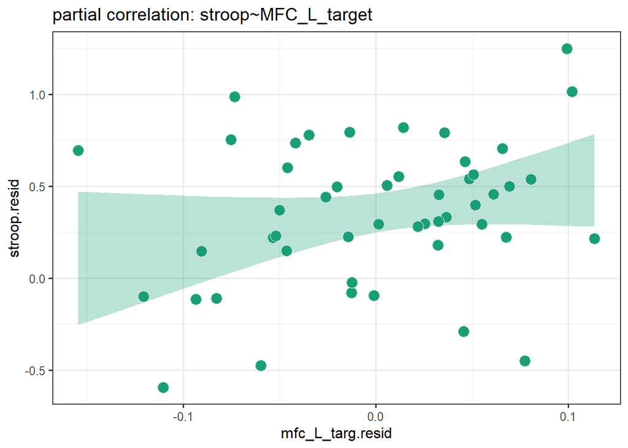

```r
resids %>%

  ggplot(., aes(mfc_L_targ.resid, stroop.resid)) +
  stat_boot_ci(n = 1E4, alpha = 0.3, fill = colors.model["target"]) +
  geom_point(color = "white", shape = 21, size = 4, fill = colors.model["target"]) +

  labs(title = "partial correlation: stroop~MFC_L_target")
```

```r
## get OLS estimates:

fits.bivar <- list(

  mfc_L_target       = lm(stroop ~ mfc_L_target, w.super %>% filter(is.analysis.group)),
  mfc_L_incongruency = lm(stroop ~ mfc_L_incongruency, w.super %>% filter(is.analysis.group)),
  lfp_R_target       = lm(stroop ~ lfp_R_target, w.super %>% filter(is.analysis.group)),
  lfp_R_incongruency = lm(stroop ~ lfp_R_incongruency, w.super %>% filter(is.analysis.group))

)
r2.bivar <- purrr::map(fits.bivar, summary) %>% purrr::map_dbl("r.squared")


fit <- lm(
  stroop ~ mfc_L_target + lfp_R_target + lfp_R_incongruency + mfc_L_incongruency,
  w.super %>% filter(is.analysis.group) %>% mutate_if(is.numeric, scale)
  )
```

```
## `mutate_if()` ignored the following grouping variables:
## Columns `scheme`, `is.analysis.group`
```

```r
summary(fit)
```

```
##
## Call:
## lm(formula = stroop ~ mfc_L_target + lfp_R_target + lfp_R_incongruency +
##     mfc_L_incongruency, data = w.super %>% filter(is.analysis.group) %>%
##     mutate_if(is.numeric, scale))
##
## Residuals:
##     Min      1Q  Median      3Q     Max
## -1.6552 -0.5306 -0.0301  0.5384  1.8887
##
## Coefficients:
##                     Estimate Std. Error t value Pr(>|t|)
## (Intercept)        -6.43e-17   1.16e-01    0.00    1.000
## mfc_L_target        3.22e-01   1.31e-01    2.45    0.018 *
## lfp_R_target       -6.30e-01   1.33e-01   -4.75  2.2e-05 ***
## lfp_R_incongruency -3.10e-02   1.36e-01   -0.23    0.821
## mfc_L_incongruency  2.15e-01   1.35e-01    1.59    0.118
## ---
## Signif. codes:  0 '***' 0.001 '**' 0.01 '*' 0.05 '.' 0.1 ' ' 1
##
## Residual standard error: 0.812 on 44 degrees of freedom
## Multiple R-squared:  0.396,  Adjusted R-squared:  0.341
## F-statistic: 7.22 on 4 and 44 DF,  p-value: 0.000147
```

```r
car::vif(fit)  ## not very collinear
```

```
##       mfc_L_target       lfp_R_target lfp_R_incongruency mfc_L_incongruency
##              1.258              1.286              1.347              1.329
```

```r
kappa(fit)  ## relatively low...
```

```
## [1] 2.289
```

```r
r2.plus <-

  fits.bivar[-grep("mfc_L_target", names(fits.bivar))] %>%

  purrr::map(function(x) update(x, . ~ . + mfc_L_target)) %>%
  purrr::map(summary) %>%
  purrr::map_dbl("r.squared")

r2.delta <- r2.plus - r2.bivar[names(r2.plus)]

r2.delta.pev <- r2.delta / r2.bivar["mfc_L_target"]  ## ~20-fold increase in variance explained....
```

### 2.3.1 results

the full double-dissociation model indicated the behavioral relevance of coding schemes differed depending on region

1. in LFP (dlpfc+lppc): stronger target coding, smaller stroop effects
   - this target–stroop association was stronger than incongruent–stroop association
2. in MFC: stronger **target** coding, not incongruent coding, larger stroop effects
   - this target–stroop association was stronger than incongruent–stroop association
   - this “swapping” of the effect (from incon to target) was due to suppression between *LFP_target* and *mfc_target*:
     - R^2 of *MFC target* predicting stroop: 0.0052
     - increase in R^2 from adding *MFC target* to model of *LFP_target* predicting stroop: 0.1028
     - that’s a 20-fold increase in variance explained

**explanantion (assuming this suppression is not spurious):**  
VIFs and condition numbers indicate this suppression effect is not due to collinearity. Rather, there are two components of target coding that explain opposing (negatively correlated) components of variance in Stroop effect. One component is reflected in LPPC/DLPFC target coding: indivs that load strongly on this component have smaller stroop (-). This (-) component is predominant. The other component is reflected in MFC target coding: indivs that load strongly on this component have larger stroop (+). However, MFC target coding also reflects, relatively weakly, this (-) component. Thus, the (+) component is observable only when the predominant, negative component has been accounted for.

# 3 Superparcel model selection and evaluation

What subset of superparcel and coding scheme combinations `best’ explain Stroop effect?

## 3.1 best-subset selection (of selected subset)

Fit a “full” model, containing all predictors, then fit models with all possible combinations of predictors. Select best model.

### 3.1.1 preliminary feature selection

```r
## (1) bivariate correlations ----

threshold <- 25  ## leq

d.super.bestsub <- d.super %<>%

  filter(is.analysis.group, !roi %in% c("lfp_R")) %>%

  group_by(id) %>%
  mutate(
    n = seq_len(n()),
    is.out.line = n %in% outpro(partr, stroop)$out.id,
    is.out.rank = n %in% outpro(rank(partr), rank(stroop))$out.id
  )

topcors <- d.super.bestsub %>%

  summarize(
    r.line = cor(beta, stroop),
    r.rank = cor(beta, stroop, method = "spearman"),
    r2.line = r.line^2,
    r2.rank = r.rank^2,
    r.line.nout = sum(is.out.line),
    r.rank.nout = sum(is.out.rank)
  ) %>%

  ungroup %>%
  filter(rank(-r2.line) < threshold & rank(-r2.rank) <= threshold) %>%
  arrange(-r2.line)

kable(topcors, digits = 2)
```

| id | r.line | r.rank | r2.line | r2.rank | r.line.nout | r.rank.nout |
| --- | --- | --- | --- | --- | --- | --- |
| dlpfc_R_target | -0.44 | -0.39 | 0.20 | 0.15 | 0 | 0 |
| lppc_R_target | -0.44 | -0.35 | 0.19 | 0.12 | 3 | 0 |
| dlpfc_L_distractor | -0.43 | -0.33 | 0.18 | 0.11 | 4 | 0 |
| vvis_L_incongruency | -0.35 | -0.43 | 0.12 | 0.18 | 2 | 0 |
| ifc_R_target | -0.30 | -0.27 | 0.09 | 0.07 | 2 | 0 |
| vpm_R_target | -0.29 | -0.17 | 0.08 | 0.03 | 2 | 0 |
| evis_incongruency | -0.27 | -0.31 | 0.07 | 0.10 | 2 | 0 |
| mfc_L_incongruency | 0.26 | 0.17 | 0.07 | 0.03 | 1 | 0 |
| dpm_L_target | -0.24 | -0.23 | 0.06 | 0.05 | 4 | 0 |
| smmouth_distractor | 0.23 | 0.25 | 0.05 | 0.06 | 1 | 0 |
| vvis_R_incongruency | -0.22 | -0.31 | 0.05 | 0.09 | 0 | 0 |
| ins_L_target | -0.19 | -0.19 | 0.04 | 0.04 | 1 | 0 |
| dlpfc_L_target | -0.19 | -0.16 | 0.04 | 0.03 | 2 | 0 |
| vwfa_incongruency | -0.18 | -0.27 | 0.03 | 0.07 | 4 | 0 |
| lppc_L_incongruency | -0.18 | -0.26 | 0.03 | 0.07 | 0 | 0 |
| lppc_R_incongruency | -0.15 | -0.18 | 0.02 | 0.03 | 0 | 0 |
| ifc_L_incongruency | -0.14 | -0.20 | 0.02 | 0.04 | 3 | 0 |
| ifc_L_target | -0.14 | -0.16 | 0.02 | 0.03 | 2 | 0 |

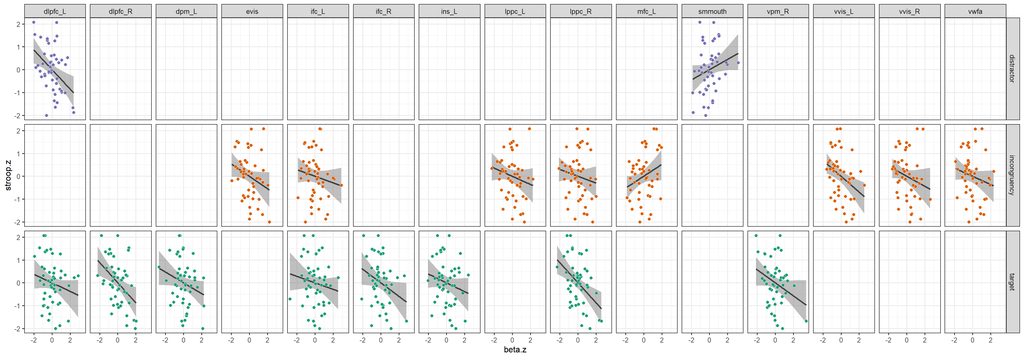

```r
## plot

d.super %>%

  filter(id %in% topcors$id) %>%

  mutate(
    beta.z = scale(beta),
    stroop.z = scale(stroop),
    r = cor(beta, stroop)
  ) %>%

  ggplot(aes(beta.z, stroop.z, fill = param)) +
  facet_grid(vars(param), vars(roi)) +

  geom_smooth(method = "lm", se = FALSE, color = "black") +
  stat_boot_ci(n = 1E4, fill = "grey50", alpha = 0.5) +
  geom_point(shape = 21, color = "white", size = 2, aes(fill = param)) +

  scale_fill_manual(values = colors.model) +
  theme(legend.position = "none")
```

This narrows it down to a set of 18 regressors.

- multple regression via OLS
- all possible combinations of selected regressors (above) will be fit
- expected test error estimated via MSE from 10-fold cross-validation
- this procedure will be repeated 5 times and MSEs averaged across repetitions
- two types of models will be noted:
  - **minimum MSE**: the model that yields minimum MSE
  - **optimal MSE**: the model(s) with fewest parameters that yield within 1 SE of **minimum MSE** model
- AIC and BIC will also be computed

```r
## build model combinations, model components

# varnames <- as.character(topcors$id)
varnames <- c(as.character(topcors$id))
nvars <- length(varnames)  ## number of predictors in full model
combs <- lapply(1:nvars, function(x) gtools::combinations(n = nvars, r = x))  ## row indicates columns of design matrix
(nmods <- sum(sapply(combs, nrow)))  ## number of models fit
```

```
## [1] 262143
```

```r
2^nvars - 1 == nmods
```

```
## [1] TRUE
```

```r
X <- as.matrix(w.super[ids$is.analysis.group, varnames])
(k <- 10)  ## k folds
```

```
## [1] 10
```

```r
(n <- nrow(X))  # n obs
```

```
## [1] 49
```

```r
## build cross-validation folds

set.seed(0)
folds <- lapply(
  1:5,
  function(.) createFolds(strooprt, k = k, list = TRUE, returnTrain = FALSE)
)
mse.rep.i <- matrix(NA, ncol = k, nrow = length(folds))  ## for storing MSEs hot off press
```

```r
## estimate test error, BIC, AIC

res <- vector("list", length(combs))  ## results
print(cbind(sapply(combs, nrow)))  ## number of models (inner loop) per combination (outer loop)
```

```
##        [,1]
##  [1,]    18
##  [2,]   153
##  [3,]   816
##  [4,]  3060
##  [5,]  8568
##  [6,] 18564
##  [7,] 31824
##  [8,] 43758
##  [9,] 48620
## [10,] 43758
## [11,] 31824
## [12,] 18564
## [13,]  8568
## [14,]  3060
## [15,]   816
## [16,]   153
## [17,]    18
## [18,]     1
```

```r
starttime <- Sys.time()
for (comb.i in seq_along(combs)) {
  # comb.i = 2

  comb <- combs[[comb.i]]

  cl <- makeCluster(n_cores - 1)
  registerDoParallel(cl)

  res[[comb.i]] <- foreach(model.i = seq_len(nrow(comb)), .inorder = FALSE, .combine = "rbind") %dorng% {
    # model.i = 2

    ## build model

    regs.i <- comb[model.i, ]  ## indices for regressors
    Xi <- cbind(b0 = 1, X[, regs.i])
    colnames(Xi)[-1] <- varnames[regs.i]

    ## get response (folds)

    for (rep.i in seq_along(folds)) {
      # rep.i = 1

      unlist.me <- lapply(

        folds[[rep.i]],

        function(., x, y) {

          xtrn <- x[-., ]
          xtst <- x[., ]
          ytrn <- y[-.]
          ytst <- y[.]
          fit  <- .lm.fit(xtrn, ytrn)
          yhat <- xtst %*% fit$coefficients

          mean((ytst - yhat)^2)

        },
        x = Xi,
        y = strooprt
      )

      mse.rep.i[rep.i, ] <- unlist(unlist.me, use.names = FALSE)

    }
    mse.i <- c(mse.rep.i)

    .mse.mean <- mean(mse.i)
    .mse.se <- sd(mse.i) / sqrt(n)

    ## AIC and BIC

    fit <- .lm.fit(Xi, strooprt)
    eps <- resid(fit)
    p <- length(coef(fit))
    .bic <- bic(eps, p)
    .aic <- aic(eps, p)

    .varnames <- list(varnames[regs.i])

    out <- data.frame(mse.mean = .mse.mean, mse.se = .mse.se, bic = .bic, aic = .aic)
    out$varnames <- .varnames

    out

  }
  stopCluster(cl)

  res[[comb.i]] <- bind_rows(res[[comb.i]], .id = "rownum")  ## to dataframe

  print(comb.i)

}
```

```
## [1] 1
## [1] 2
## [1] 3
## [1] 4
## [1] 5
## [1] 6
## [1] 7
## [1] 8
## [1] 9
## [1] 10
## [1] 11
## [1] 12
## [1] 13
## [1] 14
## [1] 15
## [1] 16
## [1] 17
## [1] 18
```

```r
(endtime <- Sys.time() - starttime)
```

```
## Time difference of 9.969 mins
```

```r
res <- bind_rows(res)

fwrite(res, here::here("out", "indif", "superparcels_best_subset.csv"))
```

### 3.1.2 results

```r
res[which.min(res$mse.mean), ]  ## minimum MSE model
```

```
##       rownum mse.mean mse.se   bic   aic
## 19034      1    608.4  54.33 468.8 453.6
##                                                                                                              varnames
## 19034 lppc_R_target, dlpfc_L_distractor, vvis_L_incongruency, mfc_L_incongruency, dlpfc_L_target, lppc_L_incongruency
```

```r
res %>%
  filter(mse.mean >= res[which.min(res$mse.mean), "mse.se"] + res[which.min(res$mse.mean), "mse.mean"]) %>%
  filter(mse.mean == min(mse.mean))  ## minimum MSE model + 1SE
```

```
##   rownum mse.mean mse.se   bic   aic
## 1      1    662.7  58.15 471.5 458.2
##                                                                                     varnames
## 1 dlpfc_R_target, lppc_R_target, dlpfc_L_distractor, mfc_L_incongruency, lppc_L_incongruency
```

```r
res[which.min(res$aic), ]  ## minimum AIC
```

```
##      rownum mse.mean mse.se   bic   aic
## 6470      1    612.1  53.71 466.1 452.9
##                                                                                             varnames
## 6470 lppc_R_target, dlpfc_L_distractor, vvis_L_incongruency, mfc_L_incongruency, lppc_L_incongruency
```

```r
res[which.min(res$bic), ]  ## minimum BIC
```

```
##      rownum mse.mean mse.se   bic   aic
## 6470      1    612.1  53.71 466.1 452.9
##                                                                                             varnames
## 6470 lppc_R_target, dlpfc_L_distractor, vvis_L_incongruency, mfc_L_incongruency, lppc_L_incongruency
```

### 3.1.3 evaluation: prediction error in held-out set

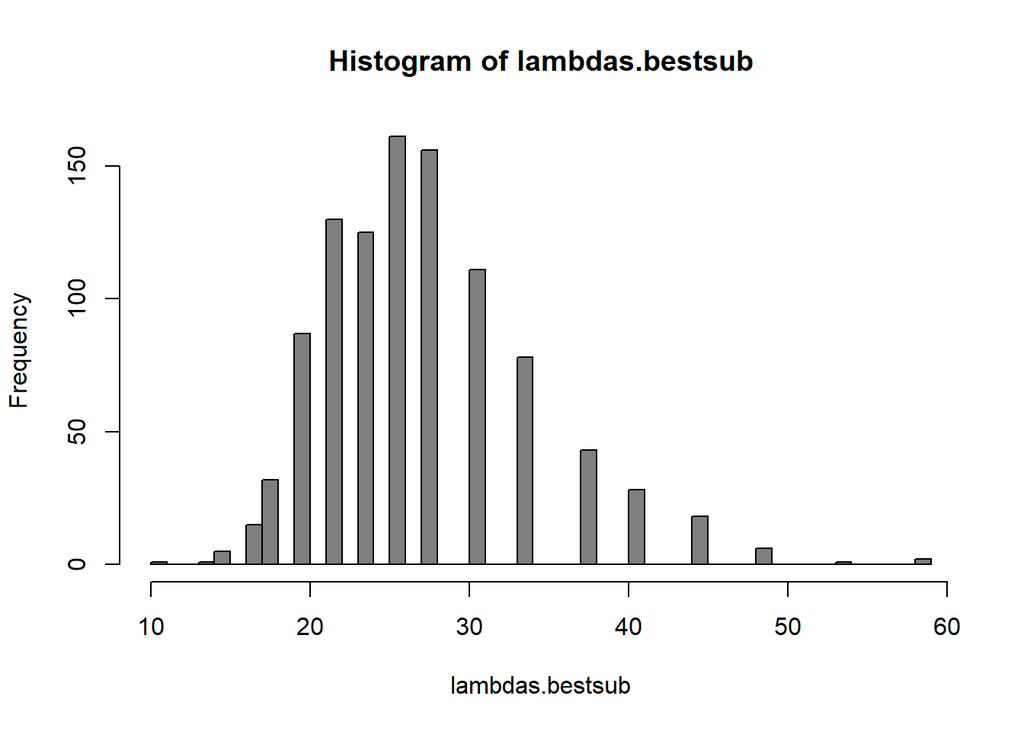

```r
## get vars ----

names.bestsub <- res[[which.min(res$bic), "varnames"]]

X.bestsub   <- m.super[ids$is.analysis.group, names.bestsub]
X.bestsub_p <- m.super[!ids$is.analysis.group, names.bestsub]

# w.bestsub <- w.super %>%
#   filter(is.analysis.group) %>%
#   ungroup %>%
#   select(one_of(names.bestsub), stroop)
# w.bestsub_p <- w.super %>%
#   filter(!is.analysis.group) %>%
#   ungroup %>%
#   select(one_of(res[[which.min(res$bic), "varnames"]]), stroop)
# X.bestsub <- cbind(1, X.bestsub)
# X.bestsub_p <- cbind(1, X.bestsub_p)

## fit ----

# ols.bestsub <- lm(stroop ~ ., w.bestsub)
# coef(ols.bestsub)

lambdas.bestsub <- tune_lambda(X.bestsub, strooprt, alpha = 0, selection_crit = function(fit) fit$lambda.1se)
hist(lambdas.bestsub, breaks = 50, col = "grey50")
```

```r
lambda.best.bestsub <- min(Mode(lambdas.bestsub))
ridge.bestsub <- glmnet(x = X.bestsub, y = strooprt, lambda = lambda.best.bestsub, alpha = 0)
coef(ridge.bestsub)
```

```
## 6 x 1 sparse Matrix of class "dgCMatrix"
##                          s0
## (Intercept)           81.07
## lppc_R_target        -78.54
## dlpfc_L_distractor  -118.10
## vvis_L_incongruency  -28.17
## mfc_L_incongruency    28.60
## lppc_L_incongruency  -24.33
```

```r
## observed error

ys.bestsub <- cbind(
  y = c(strooprt_p),
  # yhat = c(predict(ols.bestsub, newdata = w.bestsub_p))
  yhat = c(predict(ridge.bestsub, newx = X.bestsub_p))
  )

(cor.obs.bestsub <- cor(ys.bestsub)["y", "yhat"])
```

```
## [1] 0.5299
```

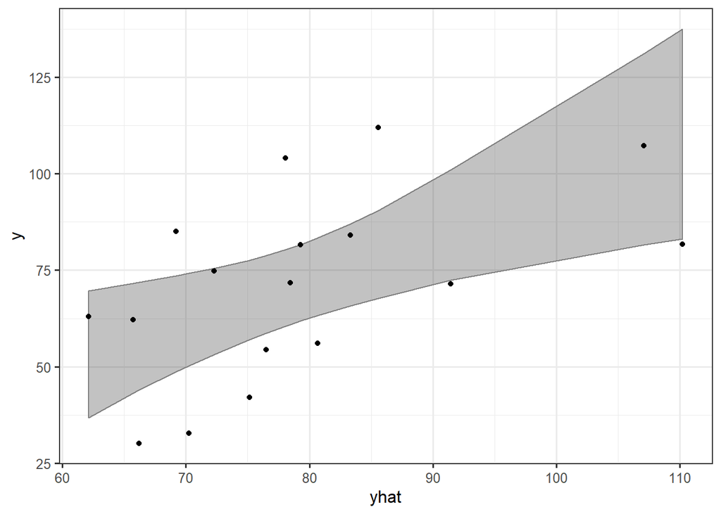

```r
ys.bestsub %>%
  as.data.frame %>%
  ggplot(aes(yhat, y)) +
  stat_boot_ci(n = 1e4, alpha = 0.3, color = "grey50") +
  geom_point()
```

```r
## permuted validation error

cl <- makeCluster(n_cores - 1)
registerDoParallel(cl)
cor.perm.bestsub <- foreach(ii = seq_len(nresamps), .inorder = FALSE, .combine = "c", .packages = "glmnet") %dorng% {

  yperm <- strooprt[sample.int(length(strooprt))]
  fit.ii <- glmnet(x = X.bestsub, y = yperm, lambda = lambda.best.bestsub, alpha = 0)

  cor(strooprt_p, predict(fit.ii, newx = X.bestsub_p))

  # fit.ii <- .lm.fit(X.bestsub, yperm)
  # c(cor(strooprt_p, X.bestsub_p %*% coef(fit.ii)))

}
stopCluster(cl)

(p.bestsub <- sum(cor.perm.bestsub > cor.obs.bestsub, na.rm = TRUE) / (nresamps - sum(is.na(cor.obs.bestsub))))
```

```
## [1] 0.0403
```

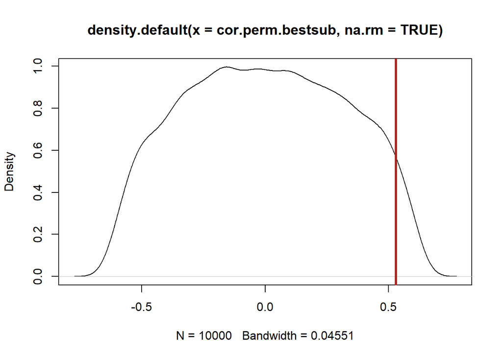

```r
plot(density(cor.perm.bestsub, na.rm = TRUE))
abline(v = cor.obs.bestsub, col = "firebrick", lwd = 3)
```

```r
sum(is.na(cor.perm.bestsub))  ## num models with no predictors
```

```
## [1] 0
```

## 3.2 elastic net selection

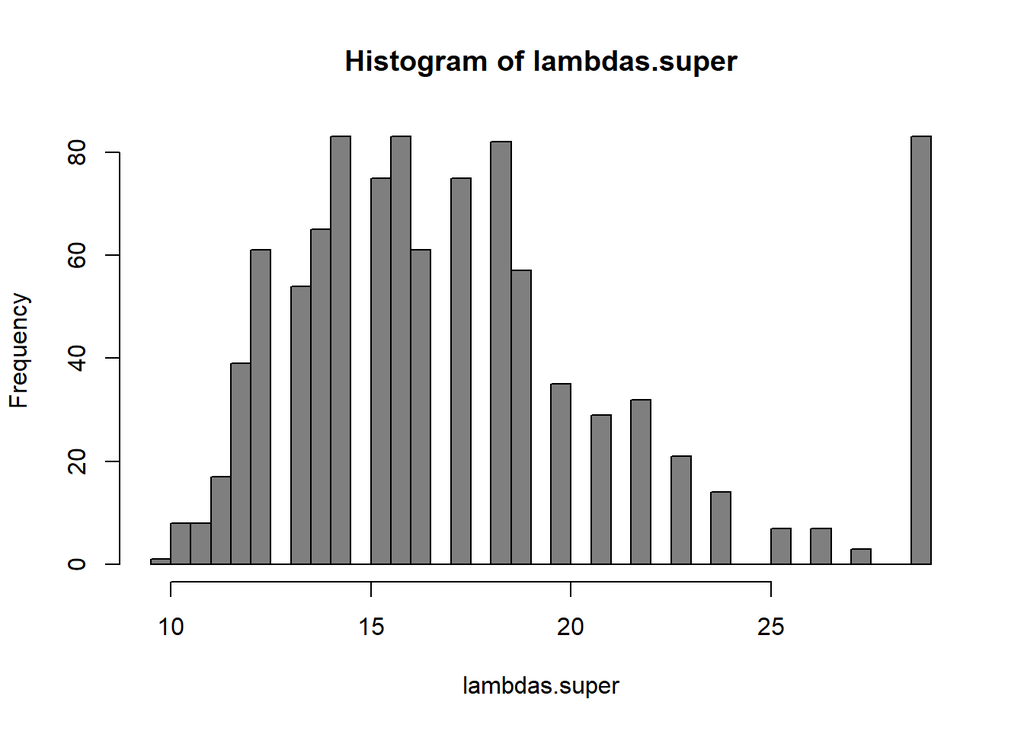

```r
## estimate model ----

X.super <- m.super[ids$is.analysis.group, -(1:2)]  ## analysis set

lambdas.super <- tune_lambda(X.super, strooprt, alpha = 0.5, selection_crit = function(fit) fit$lambda.1se)
hist(lambdas.super, breaks = 50, col = "grey50")
```

```r
lambda.best.super <- min(Mode(lambdas.super))

net.super <- glmnet(x = X.super, y = strooprt, lambda = lambda.best.super, alpha = 0.5)
coef(net.super)
```

```
## 73 x 1 sparse Matrix of class "dgCMatrix"
##                           s0
## (Intercept)           81.532
## aud_target             .
## aud_distractor         .
## aud_incongruency       .
## dlpfc_L_target         .
## dlpfc_L_distractor   -67.023
## dlpfc_L_incongruency   .
## dlpfc_R_target       -33.811
## dlpfc_R_distractor     .
## dlpfc_R_incongruency   .
## dpm_L_target           .
## dpm_L_distractor       .
## dpm_L_incongruency     .
## dpm_R_target           .
## dpm_R_distractor       .
## dpm_R_incongruency     .
## evis_target            .
## evis_distractor        .
## evis_incongruency      .
## fpc_L_target           .
## fpc_L_distractor       .
## fpc_L_incongruency     .
## fpc_R_target           .
## fpc_R_distractor       .
## fpc_R_incongruency     .
## ifc_L_target           .
## ifc_L_distractor       .
## ifc_L_incongruency     .
## ifc_R_target           .
## ifc_R_distractor       .
## ifc_R_incongruency     .
## ins_L_target           .
## ins_L_distractor       .
## ins_L_incongruency     .
## ins_R_target           .
## ins_R_distractor       .
## ins_R_incongruency     .
## lppc_L_target          .
```

[output cut: 20 more lines]

```
## vpm_L_target           .
## vpm_L_distractor       .
## vpm_L_incongruency     .
## vpm_R_target           .
## vpm_R_distractor       .
## vpm_R_incongruency     .
## vvis_L_target          .
## vvis_L_distractor      .
## vvis_L_incongruency  -11.556
## vvis_R_target          .
## vvis_R_distractor      .
## vvis_R_incongruency    .
## vwfa_target            .
## vwfa_distractor        .
## vwfa_incongruency      .
```

```r
## estimate test error ----

X.super_p <- m.super[!ids$is.analysis.group, -(1:2)]  ## 'held out' / validation set

## observed error

ys.super <- cbind(
  y = c(strooprt_p),
  yhat = c(predict(net.super, newx = X.super_p))
  )

(cor.obs.super <- cor(ys.super)["y", "yhat"])
```

```
## [1] 0.5654
```

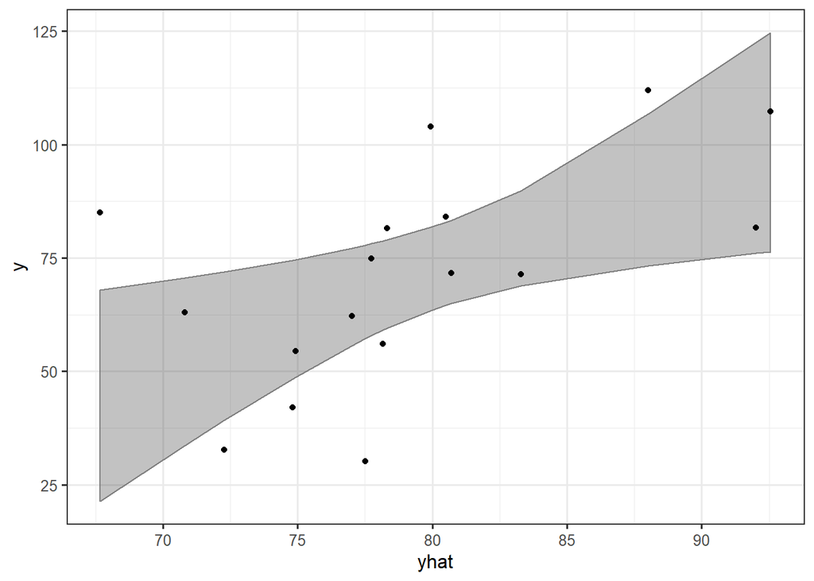

```r
ys.super %>%
  as.data.frame %>%
  ggplot(aes(yhat, y)) +
  stat_boot_ci(n = 1e4, alpha = 0.3, color = "grey50") +
  geom_point()
```

```r
## permuted validation error

cl <- makeCluster(n_cores - 1)
registerDoParallel(cl)
cor.perm.super <- foreach(ii = seq_len(nresamps), .inorder = FALSE, .combine = "c", .packages = "glmnet") %dorng% {

  yperm <- strooprt[sample.int(length(strooprt))]

  fit.ii <- glmnet(x = X.super, y = yperm, lambda = lambda.best.super, alpha = 0.5)

  cor(strooprt_p, predict(fit.ii, newx = X.super_p))

}
stopCluster(cl)

(p.super <- sum(cor.perm.super > cor.obs.super, na.rm = TRUE) / (nresamps - sum(is.na(cor.perm.super))))
```

```
## [1] 0.01583
```

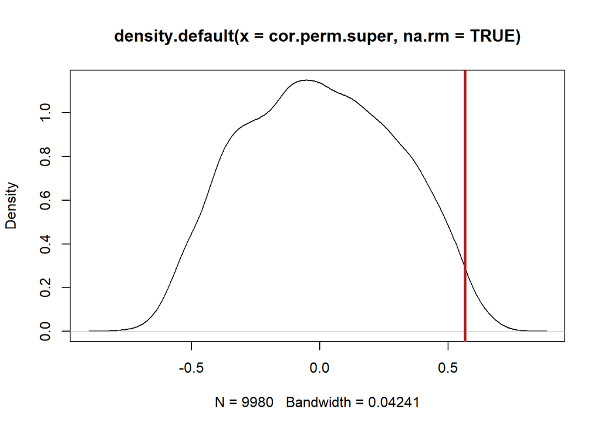

```r
plot(density(cor.perm.super, na.rm = TRUE))
abline(v = cor.obs.super, col = "firebrick", lwd = 3)
```

```r
sum(is.na(cor.perm.super))  ## num models with no predictors
```

```
## [1] 20
```

```r
glmnet.elnet <- function(alpha = 0.5, ...) glmnet.lasso(..., alpha = alpha)

## variable importance

stabs.super <- stabsel(
  x = X.super, y = strooprt, q = 10, cutoff = 0.6,
  fitfun = "glmnet.elnet",
  )
stabs.super
```

```
##  Stability Selection with unimodality assumption
##
## Selected variables:
##  dlpfc_L_distractor      dlpfc_R_target       lppc_R_target vvis_L_incongruency
##                   5                   7                  40                  66
##
## Selection probabilities:
##   mfc_R_incongruency          evis_target   fpc_L_incongruency
##                 0.00                 0.01                 0.01
##         vpm_L_target   vpm_R_incongruency         fpc_R_target
##                 0.01                 0.01                 0.02
##   fpc_R_incongruency   ifc_L_incongruency     ins_L_distractor
##                 0.02                 0.02                 0.02
##         ofc_L_target   ofc_L_incongruency   vpm_L_incongruency
##                 0.02                 0.02                 0.02
## dlpfc_L_incongruency   dpm_L_incongruency     fpc_L_distractor
##                 0.03                 0.03                 0.03
##   ifc_R_incongruency    vvis_L_distractor    vwfa_incongruency
##                 0.03                 0.03                 0.03
##   dpm_R_incongruency     ifc_R_distractor   ins_L_incongruency
##                 0.04                 0.04                 0.04
##      vwfa_distractor         ofc_R_target     vpm_L_distractor
##                 0.04                 0.05                 0.05
##     aud_incongruency       dlpfc_L_target     dpm_L_distractor
##                 0.06                 0.06                 0.06
##         dpm_R_target     ifc_L_distractor     vpm_R_distractor
##                 0.06                 0.06                 0.06
##        vvis_R_target       aud_distractor   dlpfc_R_distractor
##                 0.06                 0.07                 0.07
##     dpm_R_distractor  lppc_R_incongruency     mfc_R_distractor
##                 0.07                 0.07                 0.07
##        vvis_L_target         ins_L_target        lppc_L_target
##                 0.07                 0.09                 0.09
##         vpm_R_target      evis_distractor         fpc_L_target
##                 0.09                 0.10                 0.10
##     ins_R_distractor    lppc_R_distractor     mfc_L_distractor
##                 0.10                 0.10                 0.10
##         mfc_R_target    vvis_R_distractor         ifc_L_target
##                 0.11                 0.11                 0.12
##  lppc_L_incongruency         ins_R_target     ofc_R_distractor
##                 0.12                 0.13                 0.13
## smmouth_incongruency   ins_R_incongruency   ofc_R_incongruency
##                 0.13                 0.14                 0.14
##     fpc_R_distractor    lppc_L_distractor     ofc_L_distractor
##                 0.15                 0.15                 0.15
##  vvis_R_incongruency         dpm_L_target          vwfa_target
##                 0.16                 0.17                 0.19
##       smmouth_target         ifc_R_target dlpfc_R_incongruency
##                 0.21                 0.23                 0.27
##   smmouth_distractor         mfc_L_target           aud_target
##                 0.29                 0.32                 0.33
##    evis_incongruency   mfc_L_incongruency  vvis_L_incongruency
##                 0.40                 0.51                 0.60
##       dlpfc_R_target        lppc_R_target   dlpfc_L_distractor
##                 0.69                 0.70                 0.75
##
## ---
## Cutoff: 0.6; q: 10; PFER (*):  3.65
##    (*) or expected number of low selection probability variables
## PFER (specified upper bound):  3.655
## PFER corresponds to signif. level 0.0507 (without multiplicity adjustment)
```

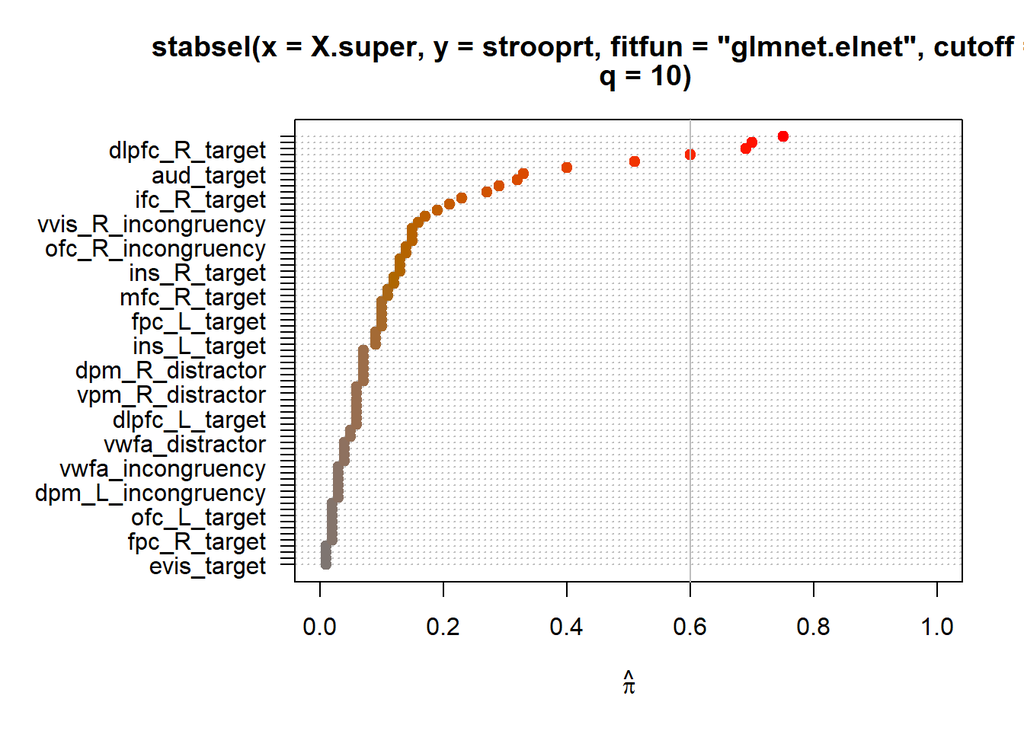

```r
plot(stabs.super)
```

# 4 MD MMP (Assem, 2020) parcel model selection and evaluation

- from set of 360 MMP parcels (180/hemisphere), 11 parcels (per hemisphere) were independently defined as commonly involved in multiple different cognitive tasks within HCP dataset (Assem, 2019)
  - strong correspondence to “multiple demand” network discussed in previous research (e.g., Duncan, Fedorenko, and colleagues).
- 11 parcels * 2 hemispheres * 3 RSA models = 66 features
- same elastic net selection and evaluation procedure as above
  - however, lambda chosen that minimizes CV test error (not min+1SE)
  - in lambda = min+1se, no variables were selected

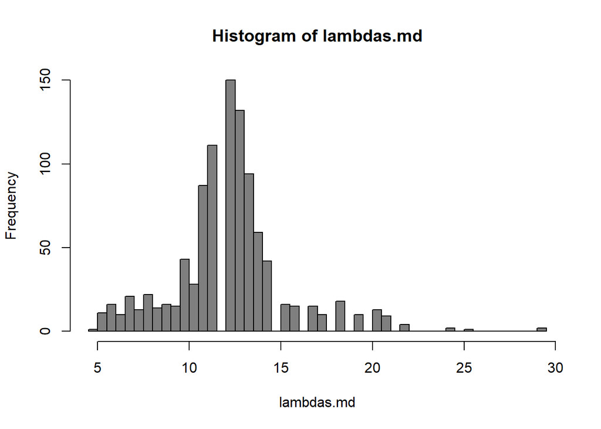

```r
names.md <- colnames(w.mmp)[grep(paste0(md$core, collapse = "|"), colnames(w.mmp))]

## estimate model ----

X.md <- m.mmp[ids$is.analysis.group, names.md]

## find lambda and fit

lambdas.md <- tune_lambda(X.md, strooprt, alpha = 0.5, selection_crit = function(fit) fit$lambda.min)
hist(lambdas.md, breaks = 50, col = "grey50")
```

```r
lambda.best.md <- min(Mode(lambdas.md))

net.md <- glmnet(x = X.md, y = strooprt, lambda = lambda.best.md, alpha = 0.5)
coef(net.md)
```

```
## 67 x 1 sparse Matrix of class "dgCMatrix"
##                            s0
## (Intercept)            82.394
## SCEF_L_target           .
## SCEF_L_distractor       .
## SCEF_L_incongruency     .
## 8BM_L_target            .
## 8BM_L_distractor        .
## 8BM_L_incongruency      .
## 8C_L_target             .
## 8C_L_distractor         .
## 8C_L_incongruency       .
## IFJp_L_target           .
## IFJp_L_distractor      -2.847
## IFJp_L_incongruency     .
## p9-46v_L_target         .
## p9-46v_L_distractor   -46.530
## p9-46v_L_incongruency   .
## a9-46v_L_target         .
## a9-46v_L_distractor   -33.651
## a9-46v_L_incongruency   .
## i6-8_L_target           .
## i6-8_L_distractor       .
## i6-8_L_incongruency     .
## AVI_L_target            .
## AVI_L_distractor      -18.886
## AVI_L_incongruency      .
## IP2_L_target            .
## IP2_L_distractor        .
## IP2_L_incongruency      .
## IP1_L_target            .
## IP1_L_distractor        .
## IP1_L_incongruency      .
## PFm_L_target            .
## PFm_L_distractor        .
## PFm_L_incongruency    -10.340
## SCEF_R_target           .
## SCEF_R_distractor       .
## SCEF_R_incongruency     .
## 8BM_R_target            .
```

[output cut: 14 more lines]

```
## i6-8_R_target         -61.756
## i6-8_R_distractor       .
## i6-8_R_incongruency     .
## AVI_R_target            .
## AVI_R_distractor        .
## AVI_R_incongruency      .
## IP2_R_target            .
## IP2_R_distractor        .
## IP2_R_incongruency      .
## IP1_R_target          -42.235
## IP1_R_distractor      -40.406
## IP1_R_incongruency      .
## PFm_R_target            .
## PFm_R_distractor        .
## PFm_R_incongruency      .
```

```r
## estimate test error ----

X.md_p <- m.mmp[!ids$is.analysis.group, names.md]  ## 'held out' / validation set

## observed error

ys.md <- cbind(
  y = c(strooprt_p),
  yhat = c(predict(net.md, newx = X.md_p))
  )

(cor.obs.md <- cor(ys.md)["y", "yhat"])
```

```
## [1] 0.5749
```

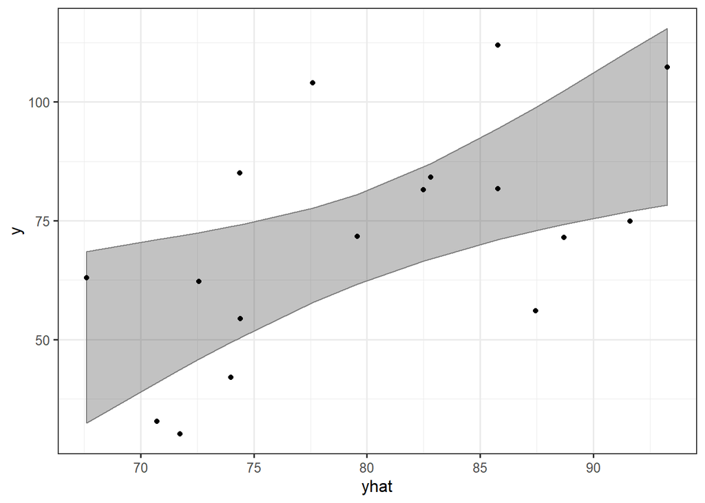

```r
ys.md %>%
  as.data.frame %>%
  ggplot(aes(yhat, y)) +
  stat_boot_ci(n = 1e4, alpha = 0.3, color = "grey50") +
  geom_point()
```

```r
## permuted validation error

cl <- makeCluster(n_cores - 1)
registerDoParallel(cl)
cor.perm.md <- foreach(ii = seq_len(nresamps), .inorder = FALSE, .combine = "c", .packages = "glmnet") %dorng% {

  yperm <- strooprt[sample.int(length(strooprt))]

  fit.ii <- glmnet(x = X.md, y = yperm, lambda = lambda.best.md, alpha = 0.5)

  cor(strooprt_p, predict(fit.ii, newx = X.md_p))

}
stopCluster(cl)

(p.md <- sum(cor.perm.md > cor.obs.md, na.rm = TRUE) / (nresamps - sum(is.na(cor.perm.md))))
```

```
## [1] 0.0252
```

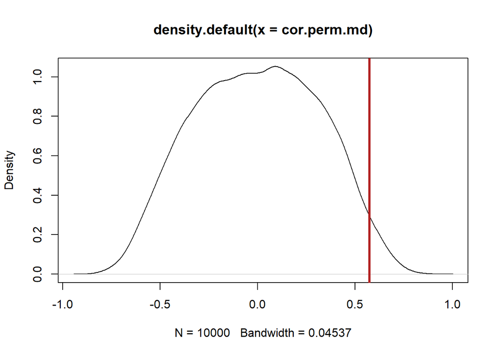

```r
plot(density(cor.perm.md))
abline(v = cor.obs.md, col = "firebrick", lwd = 3)
```

```r
sum(is.na(cor.perm.md))
```

```
## [1] 0
```

```r
## variable importance

stabs.md <- stabsel(
  x = X.md, y = strooprt, q = 10, cutoff = 0.6,
  fitfun = "glmnet.elnet",
  )
stabs.md
```

```
##  Stability Selection with unimodality assumption
##
## Selected variables:
## i6-8_R_target  IP1_R_target
##            52            61
##
## Selection probabilities:
##       a9-46v_L_target    8BM_R_incongruency      PFm_R_distractor
##                  0.01                  0.01                  0.01
##         i6-8_L_target p9-46v_R_incongruency     8C_L_incongruency
##                  0.02                  0.02                  0.03
##           8C_R_target a9-46v_R_incongruency    IP2_R_incongruency
##                  0.03                  0.03                  0.03
##         SCEF_L_target p9-46v_L_incongruency a9-46v_L_incongruency
##                  0.04                  0.04                  0.04
##       8C_R_distractor   p9-46v_R_distractor       a9-46v_R_target
##                  0.04                  0.04                  0.04
##   SCEF_R_incongruency      8BM_R_distractor    PFm_R_incongruency
##                  0.05                  0.05                  0.05
##           8C_L_target          AVI_L_target   a9-46v_R_distractor
##                  0.06                  0.06                  0.06
##    AVI_R_incongruency       p9-46v_L_target      IP2_L_distractor
##                  0.06                  0.07                  0.07
##         IFJp_R_target    8BM_L_incongruency      IP1_L_distractor
##                  0.07                  0.08                  0.08
##      8BM_L_distractor         IFJp_L_target   i6-8_L_incongruency
##                  0.09                  0.09                  0.09
##          IP2_L_target          IP1_L_target          8BM_R_target
##                  0.09                  0.09                  0.09
##     SCEF_R_distractor     i6-8_R_distractor          IP2_R_target
##                  0.11                  0.11                  0.11
##    IP1_L_incongruency   IFJp_R_incongruency          PFm_R_target
##                  0.12                  0.12                  0.12
##          8BM_L_target      AVI_R_distractor     SCEF_L_distractor
##                  0.13                  0.13                  0.14
##   SCEF_L_incongruency     8C_R_incongruency     IFJp_R_distractor
##                  0.14                  0.14                  0.14
##          AVI_R_target      PFm_L_distractor   i6-8_R_incongruency
##                  0.14                  0.16                  0.16
##      IP2_R_distractor     i6-8_L_distractor    AVI_L_incongruency
##                  0.17                  0.18                  0.18
##          PFm_L_target         SCEF_R_target    IP2_L_incongruency
##                  0.18                  0.18                  0.20
##       8C_L_distractor    IP1_R_incongruency       p9-46v_R_target
##                  0.21                  0.22                  0.23
##   IFJp_L_incongruency     IFJp_L_distractor      AVI_L_distractor
##                  0.28                  0.31                  0.32
##   a9-46v_L_distractor    PFm_L_incongruency   p9-46v_L_distractor
##                  0.37                  0.42                  0.56
##      IP1_R_distractor          IP1_R_target         i6-8_R_target
##                  0.58                  0.66                  0.77
##
## ---
## Cutoff: 0.6; q: 10; PFER (*):  3.99
##    (*) or expected number of low selection probability variables
## PFER (specified upper bound):  3.987
## PFER corresponds to signif. level 0.0605 (without multiplicity adjustment)
```

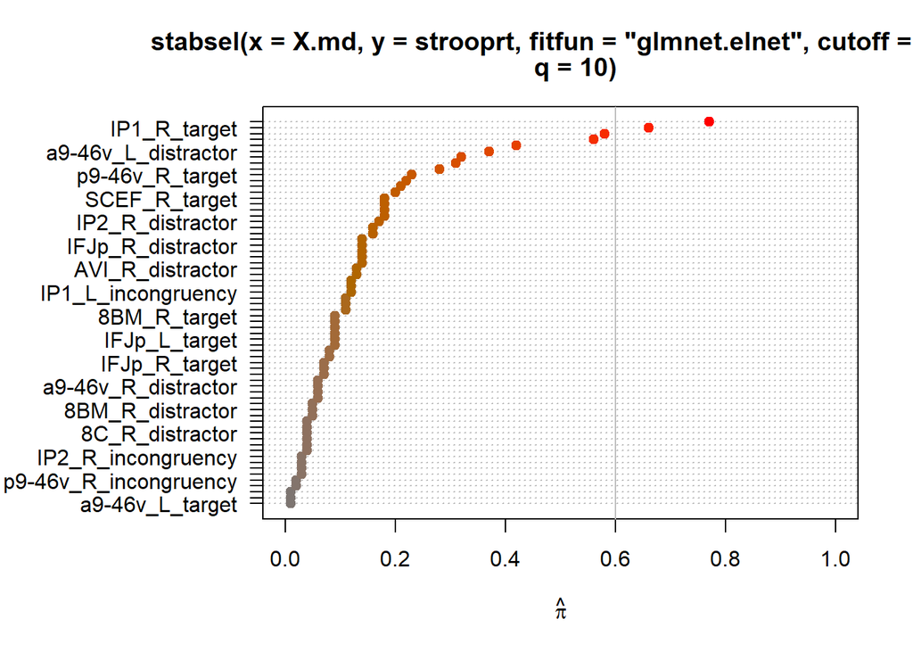

```r
plot(stabs.md)
```